# Tugas Pertemuan 1

Siti Zahra Muthmainnah

2026-08-30

## Library/Packages

```r
library("forecast")
```

```r
library("graphics")
library("TTR")
library("TSA")
```

## Impor Data

```r
library(rio)
library(readxl)
d <- read_excel("D://IPB//5. Semester 5//ADW/dataset pm2.5 SPLITTED.xlsx", sheet = "MUTI")
```

## Eksplorasi Data

```r
str(d)
```

```
## tibble [155 × 3] (S3: tbl_df/tbl/data.frame)
##  $ tanggal: POSIXct[1:155], format: "2023-11-11" "2023-11-12" ...
##  $ stasiun: chr [1:155] "DKI1 (Bunderan HI)" "DKI1 (Bunderan HI)" "DKI1 (Bunderan HI)" "DKI1 (Bunderan HI)" ...
##  $ pm25   : num [1:155] 89 79 81 79 66 81 75 120 80 75 ...
```

```r
dim(d)
```

```
## [1] 155   3
```

Mengubah data agar terbaca sebagai data deret waktu dengan fungsi `ts()` .

```r
d.ts <- ts(d$pm25)
```

Menampilkan ringkasan data

```r
summary(d.ts)
```

```
##    Min. 1st Qu.  Median    Mean 3rd Qu.    Max.
##   18.00   49.00   61.00   61.37   75.00  120.00
```

Membuat plot data deret waktu

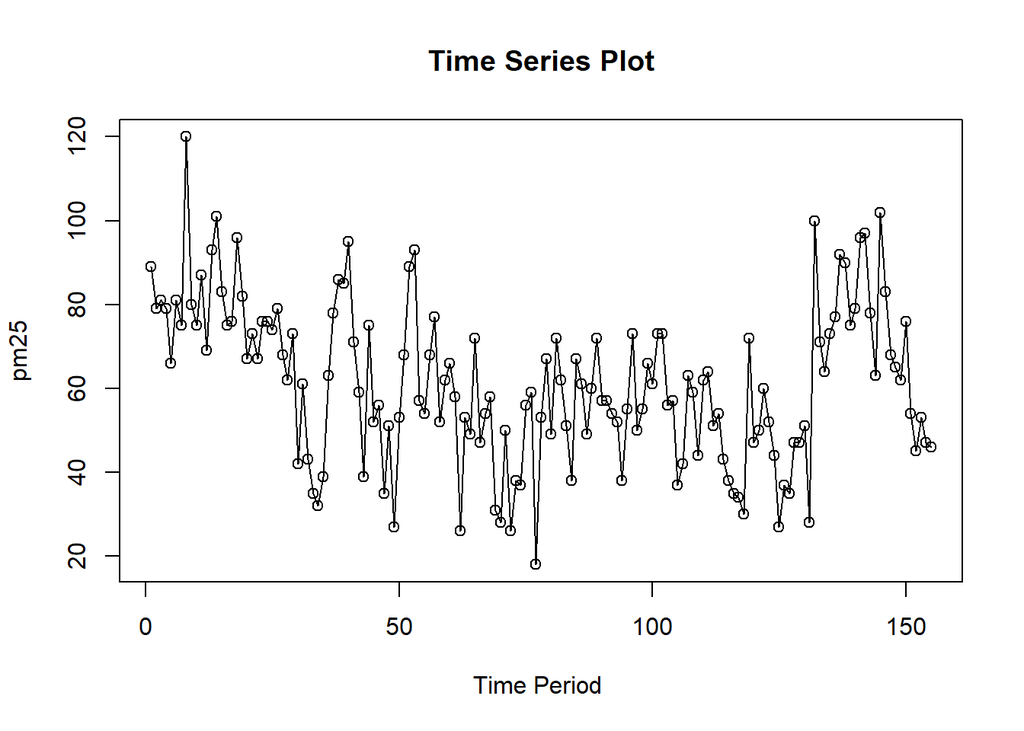

```r
ts.plot(d.ts, xlab="Time Period ", ylab="pm25",
        main = "Time Series Plot")
points(d.ts)
```

```r
#menyimpan plot
dev.copy(png, "plot_d.png")
```

```r
dev.off()
```

## Moving Average

### Pembagian Data

Pembagian data latih dan data uji dilakukan dengan perbandingan 80% data latih dan 20% data uji.

```r
# hitung jumlah data
n <- nrow(d)

# tentukan batas 80%
n_train <- floor(0.8 * n)

# bagi data
training_ma <- d[1:n_train, ]
testing_ma  <- d[(n_train+1):n, ]

# ubah ke time series
train_ma.ts <- ts(training_ma$pm25)
test_ma.ts  <- ts(testing_ma$pm25)
```

Eksplorasi data dilakukan pada keseluruhan data, data latih serta data uji menggunakan plot data deret waktu.

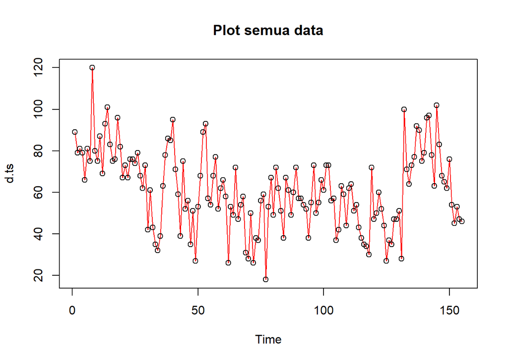

```r
#eksplorasi keseluruhan data
plot(d.ts, col="red",main="Plot semua data")
points(d.ts)
```

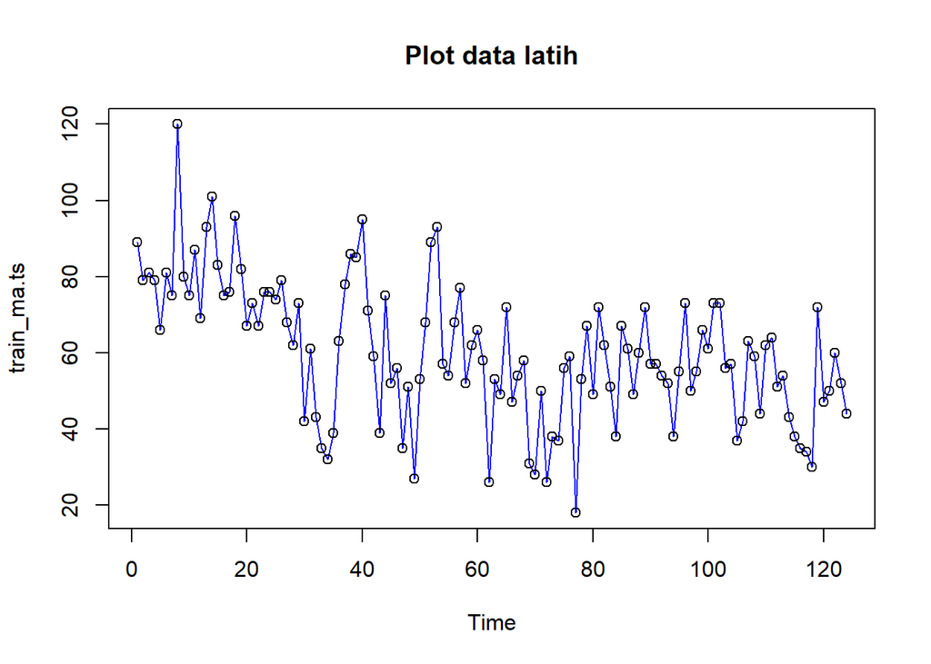

```r
#eksplorasi data latih
plot(train_ma.ts, col="blue",main="Plot data latih")
points(train_ma.ts)
```

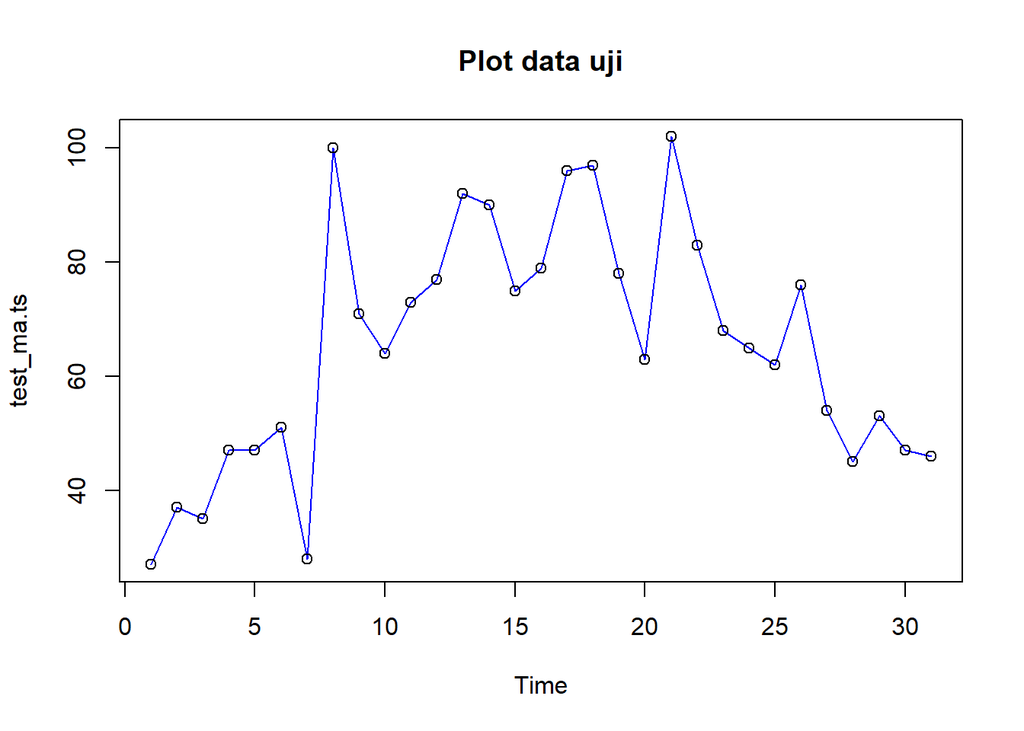

```r
#eksplorasi data uji
plot(test_ma.ts, col="blue",main="Plot data uji")
points(test_ma.ts)
```

Eksplorasi data juga dapat dilakukan menggunakan package `ggplot2` dengan terlebih dahulu memanggil library *package* `ggplot2`.

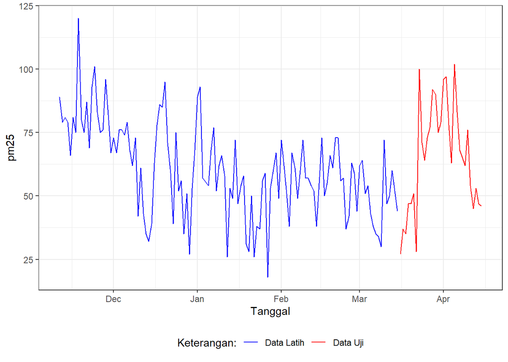

```r
library(ggplot2)
ggplot() +
  geom_line(data = training_ma, aes(x = tanggal, y = pm25, col = "Data Latih")) +
  geom_line(data = testing_ma, aes(x = tanggal, y = pm25, col = "Data Uji")) +
  labs(x = "Tanggal", y = "pm25", color = "Legend") +
   scale_colour_manual(name="Keterangan:", breaks = c("Data Latih", "Data Uji"),
                      values = c("blue", "red")) +
  theme_bw() + theme(legend.position = "bottom",
                     plot.caption = element_text(hjust=0.5, size=12))
```